# Enrichment of *de novo* Regulatory Variants in DDD

Patrick Short

March 25, 2015

This analysis uses several different data sources: 1. DDD 4k variant calls in non-coding regions of the genome. 2. Catalogue of well-covered regulatory regions in the DDD 4k target-capture set (courtesy of Dan King) 3. Trinucleotide Mutation rates derived from 1000 Genomes data (courtesy of Jeremey McRae) 4. Gencode v19

To build a null-model for regulatory mutation burden by gene, we must first assign all of the well-covered regulatory regions in the target set to one of the Gencode v19 genes. This assignment process follows two simple rules: 1. If the target region is contained entirely between the transcription start and stop site of a gene, it is assigned to that gene. 2. If not fully contained by some gene, the region is assigned to the gene with the closest downstream transcription start site.

The data contains 6827 well-covered regulatory regions. These regions have been assigned to 2285 different genes. The number of regulatory regions per gene is plotted below:

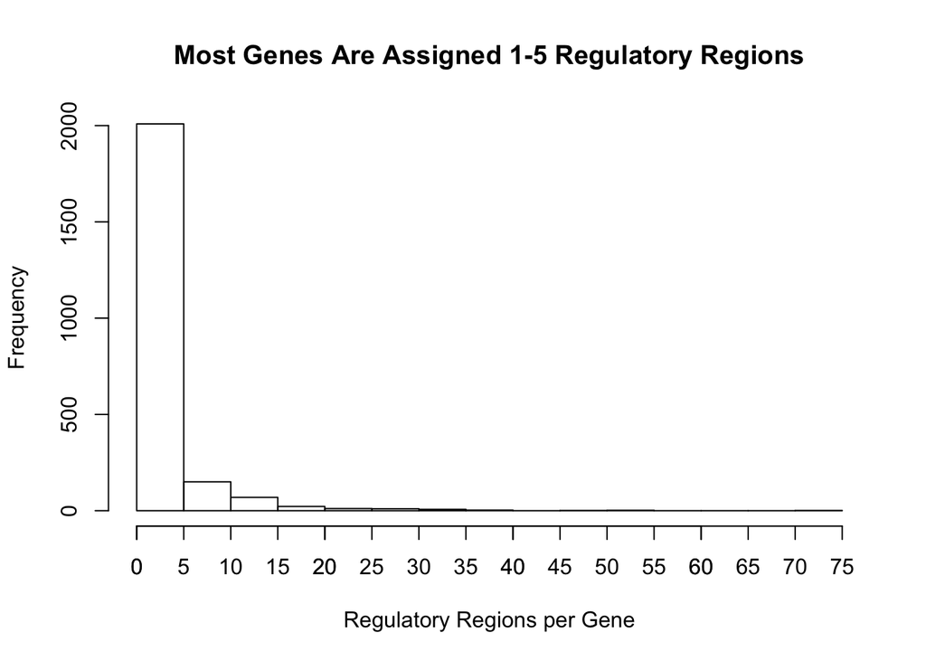

The DDD 4k exome data contains 5982 noncoding *de novo* variants in 524 probands. As we have already mapped the 6827 well-covered regulatory regions to the closest gene, we can filter the DDD 4k exome noncoding variants for those that lie in the well-covered regulatory regions and assign these to the closest gene in the same manner.

There are 573 well-covered regulatory variants. For 87 of these 573 variants, the closest gene is in the DDG2P freeze used in this analysis.

Controlling the p-values generated here for a false discovery rate at the alpha = 0.05 level (1 in 20 ‘discoveries’ will be a false positive) leaves several genes in the table below that we have strong reason to follow up on:

|  | name | regulatory_regions | in_ddg2p | observed_regulatory_denovos | p_null | p_regulatory | fdr_regulatory |
| --- | --- | --- | --- | --- | --- | --- | --- |
| 33 | EBF2 | 11 | FALSE | 5 | 0.2966940 | 1.42e-05 | 0.0125303 |
| 245 | BCLAF1 | 1 | FALSE | 3 | 0.0269447 | 3.20e-06 | 0.0072519 |
| 271 | EPHA5 | 1 | FALSE | 3 | 0.0469439 | 1.65e-05 | 0.0125303 |